# Had Active Credit.

### Кредиты наличными.

#### **Оценка качества выдач от наличия активного кредита в момент подачи заявки и времени с момента его открытия.**

##### Критерий качества - was.ovd90.12m.

###### *Галкин Михаил, авг.2017*

###### Примечание: - Брал 0 месяц назад (mon.0)– т.е. с момента взятия кредита прошло от 1 до 30 дней. - Брал 1 месяц назад (mon.1)– т.е. с момента взятия кредита прошло от 31 до 60 дней и т.д. - Брал 2 месяц назад (mon.2)– т.е. с момента взятия кредита прошло от 61 до 90 дней и т.д.

#### Исходные данные.

- 83 924 выданных кредитов наличными по заявкам за период [03.01.2014 - 30.06.2016]

| Показатель | Значение |
| --- | --- |
| 1 : Выдано КН, # | 83924 |
| 2 : was.ovd90.12m в (1), % | 3.07182689099662 |
| 3 : Имел активный кредит, # | 53015 |
| 4 : Доля (3) в выданных (1), % | 63.1702492731519 |
| 5 : was.ovd90.12m в (3), # | 1727 |
| 6 : was.ovd90.12m в (3), % | 3.2575686126568 |

Среди тех клиентов, которые **имели хотя бы 1 активный кредит** на момент заявки, чётко видна зависимость уровня дефолта от количества месяцев прошедших после открытия последнего активного кредита.

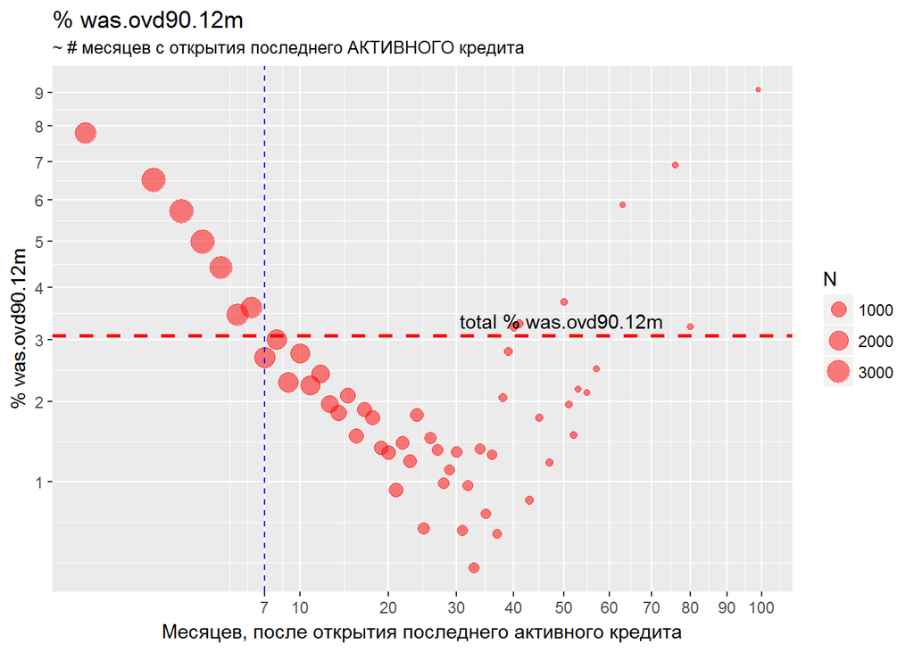

Среди же тех, кто **не имел ни одного активного кредита** на момент заявки - уровень дефолта ниже среднего и не имеет явной зависимости от прошедшего времени после открытия последнего кредита. Дефолтность выше среднего наблюдается у тех, кто брал кредиты последний раз более чем 5 лет назад.

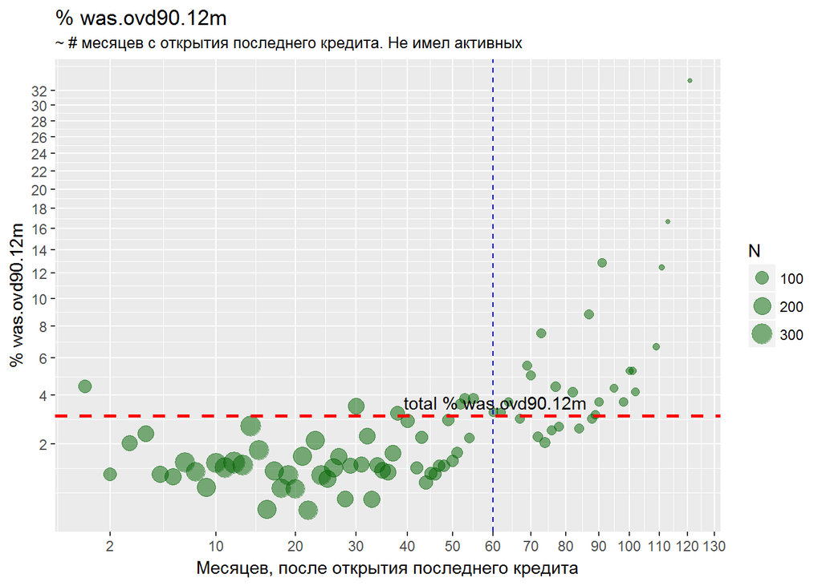

#### Копнём тех, кто имел активные кредиты.

По каждому срезу сначала будут показаны диаграммы, затем сразу соответствующие им таблицы, усечённые до давности открытия в 12 месяцев.

#### Итак:

##### Предодобренные vs. Не предодобренные.

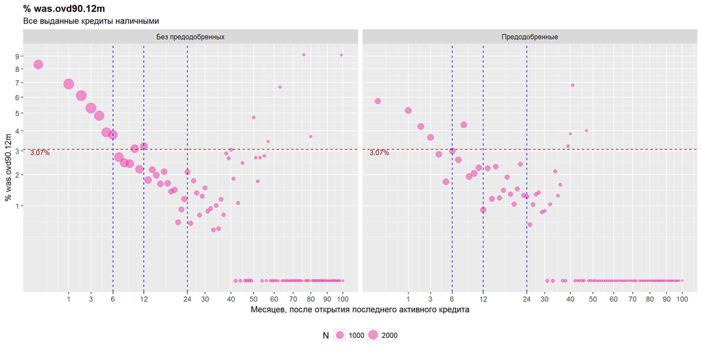

Кол-во выданных (N) и дефолт (was90%) по ним, по времени после открытия последнего активного кредита

| Параметр | ~ | Всего | в т.ч. НЕ имел активных | mon.0 | mon.1 | mon.2 | mon.3 | mon.4 | mon.5 | mon.6 | mon.7 | mon.8 | mon.9 | mon.10 | mon.11 | mon.12 |
| --- | --- | --- | --- | --- | --- | --- | --- | --- | --- | --- | --- | --- | --- | --- | --- | --- |
| Выдано КН | N | 83 924 | 30 909 | 2 538 | 3 578 | 3 503 | 3 454 | 3 168 | 2 947 | 2 675 | 2 450 | 2 304 | 2 187 | 2 103 | 2 011 | 1 612 |
| Выдано КН | was90% | 3.072 | 2.753 | 7.801 | 6.512 | 5.709 | 4.98 | 4.419 | 3.461 | 3.589 | 2.694 | 2.995 | 2.286 | 2.758 | 2.238 | 2.419 |
| Гарант | N | 32 154 | 17 700 | 522 | 757 | 732 | 684 | 667 | 630 | 666 | 614 | 645 | 671 | 684 | 658 | 562 |
| Гарант | was90% | 2.703 | 2.944 | 5.747 | 5.152 | 4.235 | 3.655 | 2.849 | 1.746 | 3.003 | 2.606 | 4.341 | 1.937 | 2.047 | 2.28 | 0.89 |
| Не гарант | N | 51 770 | 13 209 | 2 016 | 2 821 | 2 771 | 2 770 | 2 501 | 2 317 | 2 009 | 1 836 | 1 659 | 1 516 | 1 419 | 1 353 | 1 050 |
| Не гарант | was90% | 3.301 | 2.498 | 8.333 | 6.877 | 6.099 | 5.307 | 4.838 | 3.927 | 3.783 | 2.723 | 2.471 | 2.441 | 3.101 | 2.217 | 3.238 |

##### Предодобренные по Волнам и Top-up.

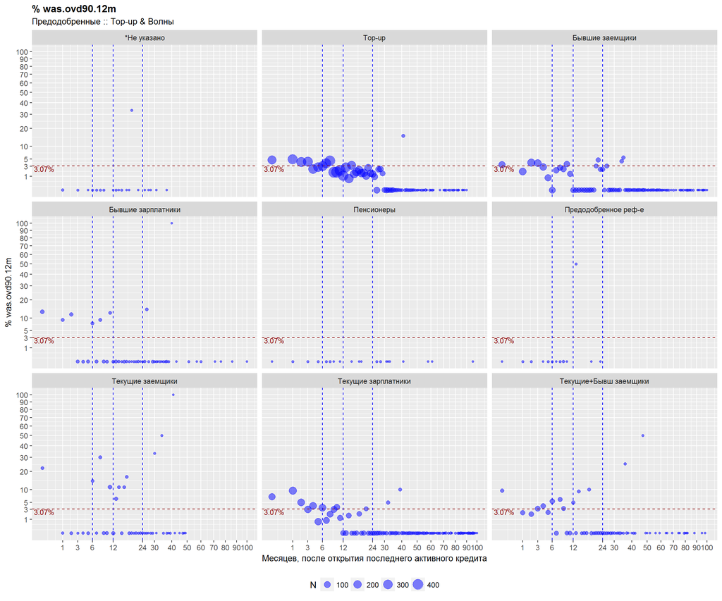

Кол-во выданных (N) и дефолт (was90%) по ним, по времени после открытия последнего активного кредита

| Параметр | ~ | Всего | в т.ч. НЕ имел активных | mon.0 | mon.1 | mon.2 | mon.3 | mon.4 | mon.5 | mon.6 | mon.7 | mon.8 | mon.9 | mon.10 | mon.11 | mon.12 |
| --- | --- | --- | --- | --- | --- | --- | --- | --- | --- | --- | --- | --- | --- | --- | --- | --- |
| Missing | N | 94 | 56 | NA | 5 | NA | 3 | NA | 1 | 3 | 3 | 2 | 3 | NA | NA | 1 |
| Missing | was90% | 2.128 | 1.786 | NA | 0 | NA | 0 | NA | 0 | 0 | 0 | 0 | 0 | NA | NA | 0 |
| Top-up | N | 17 141 | 9 062 | 233 | 342 | 315 | 308 | 305 | 288 | 326 | 351 | 403 | 425 | 473 | 446 | 374 |
| Top-up | was90% | 2.8 | 3.178 | 4.721 | 4.971 | 4.127 | 4.221 | 2.295 | 2.778 | 3.067 | 3.704 | 4.467 | 1.647 | 1.691 | 2.018 | 1.07 |
| Бывшие заемщики | N | 6 038 | 3 502 | 118 | 167 | 177 | 159 | 142 | 129 | 110 | 97 | 76 | 87 | 85 | 72 | 72 |
| Бывшие заемщики | was90% | 2.004 | 2.227 | 3.39 | 1.796 | 3.955 | 3.774 | 2.817 | 0.775 | 0 | 2.062 | 2.632 | 2.299 | 3.529 | 1.389 | 0 |
| Бывшие зарплатники | N | 423 | 172 | 23 | 11 | 17 | 11 | 9 | 13 | 13 | 14 | 11 | 10 | 6 | 8 | 6 |
| Бывшие зарплатники | was90% | 4.019 | 3.488 | 13.043 | 9.091 | 11.765 | 0 | 0 | 0 | 7.692 | 0 | 9.091 | 0 | 0 | 12.5 | 0 |
| Пенсионеры | N | 114 | 81 | 1 | 2 | NA | 3 | NA | 3 | NA | 2 | 3 | 1 | NA | 1 | NA |
| Пенсионеры | was90% | 0.877 | 1.235 | 0 | 0 | NA | 0 | NA | 0 | NA | 0 | 0 | 0 | NA | 0 | NA |
| Предодобренное реф-е | N | 23 | NA | 1 | 2 | 3 | NA | 1 | 2 | 2 | 1 | 2 | 4 | 1 | NA | NA |
| Предодобренное реф-е | was90% | 4.348 | NA | 0 | 0 | 0 | NA | 0 | 0 | 0 | 0 | 0 | 0 | 0 | NA | NA |
| Текущие заемщики | N | 242 | 8 | 9 | 4 | 7 | 3 | 4 | 9 | 7 | 4 | 10 | 10 | 12 | 27 | 20 |
| Текущие заемщики | was90% | 6.612 | 0 | 22.222 | 0 | 0 | 0 | 0 | 0 | 14.286 | 0 | 30 | 0 | 0 | 11.111 | 0 |
| Текущие зарплатники | N | 6 123 | 3 578 | 116 | 179 | 162 | 134 | 155 | 141 | 149 | 112 | 105 | 100 | 84 | 81 | 69 |
| Текущие зарплатники | was90% | 2.956 | 3.27 | 6.897 | 9.497 | 4.938 | 2.985 | 3.871 | 0.709 | 3.356 | 0.893 | 1.905 | 3 | 3.571 | 1.235 | 0 |
| Текущие+Бывш заемщики | N | 1 956 | 1 241 | 21 | 45 | 51 | 63 | 51 | 44 | 56 | 30 | 33 | 31 | 23 | 23 | 20 |
| Текущие+Бывш заемщики | was90% | 2.556 | 2.417 | 9.524 | 2.222 | 1.961 | 3.175 | 3.922 | 2.273 | 5.357 | 0 | 6.061 | 3.226 | 0 | 0 | 5 |

#### По типу активного кредита:

##### Предодобренные.

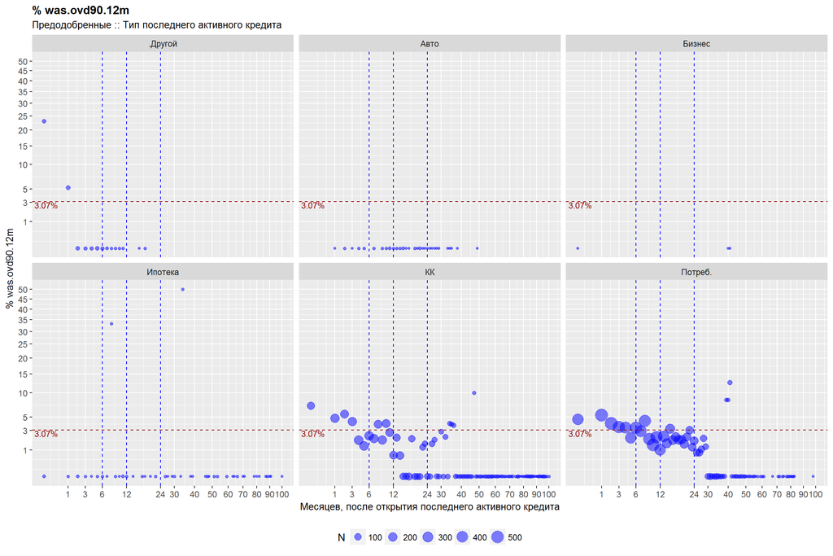

Кол-во выданных (N) и дефолт (was90%) по ним, по времени после открытия последнего активного кредита

| Параметр | ~ | Всего | в т.ч. НЕ имел активных | mon.0 | mon.1 | mon.2 | mon.3 | mon.4 | mon.5 | mon.6 | mon.7 | mon.8 | mon.9 | mon.10 | mon.11 | mon.12 |
| --- | --- | --- | --- | --- | --- | --- | --- | --- | --- | --- | --- | --- | --- | --- | --- | --- |
| Garant:Type:.Другой | N | 97 | NA | 13 | 19 | 12 | 7 | 9 | 12 | 7 | 4 | 3 | 2 | 3 | 3 | NA |
| Garant:Type:.Другой | was90% | 4.124 | NA | 23.077 | 5.263 | 0 | 0 | 0 | 0 | 0 | 0 | 0 | 0 | 0 | 0 | NA |
| Garant:Type:Missing | N | 17 700 | 17 700 | NA | NA | NA | NA | NA | NA | NA | NA | NA | NA | NA | NA | NA |
| Garant:Type:Missing | was90% | 2.944 | 2.944 | NA | NA | NA | NA | NA | NA | NA | NA | NA | NA | NA | NA | NA |
| Garant:Type:Авто | N | 53 | NA | NA | 1 | 3 | 1 | 3 | 2 | NA | 2 | NA | 2 | 2 | 5 | 2 |
| Garant:Type:Авто | was90% | 0 | NA | NA | 0 | 0 | 0 | 0 | 0 | NA | 0 | NA | 0 | 0 | 0 | 0 |
| Garant:Type:Бизнес | N | 3 | NA | 1 | NA | NA | NA | NA | NA | NA | NA | NA | NA | NA | NA | NA |
| Garant:Type:Бизнес | was90% | 0 | NA | 0 | NA | NA | NA | NA | NA | NA | NA | NA | NA | NA | NA | NA |
| Garant:Type:Ипотека | N | 84 | NA | 4 | 2 | 5 | 2 | 1 | 3 | 2 | 1 | 3 | 3 | 1 | 4 | 3 |
| Garant:Type:Ипотека | was90% | 2.381 | NA | 0 | 0 | 0 | 0 | 0 | 0 | 0 | 0 | 33.333 | 0 | 0 | 0 | 0 |
| Garant:Type:КК | N | 4 575 | NA | 141 | 207 | 181 | 210 | 214 | 229 | 212 | 193 | 181 | 209 | 176 | 184 | 154 |
| Garant:Type:КК | was90% | 2.077 | NA | 7.092 | 4.831 | 5.525 | 4.286 | 1.869 | 1.31 | 2.358 | 2.073 | 3.867 | 1.914 | 3.977 | 2.717 | 0.649 |
| Garant:Type:Потреб. | N | 9 642 | NA | 363 | 528 | 531 | 464 | 440 | 384 | 445 | 414 | 458 | 455 | 502 | 462 | 403 |
| Garant:Type:Потреб. | was90% | 2.562 | NA | 4.683 | 5.303 | 3.955 | 3.448 | 3.409 | 2.083 | 3.371 | 2.899 | 4.367 | 1.978 | 1.394 | 2.165 | 0.993 |

##### НЕ предодобренные.

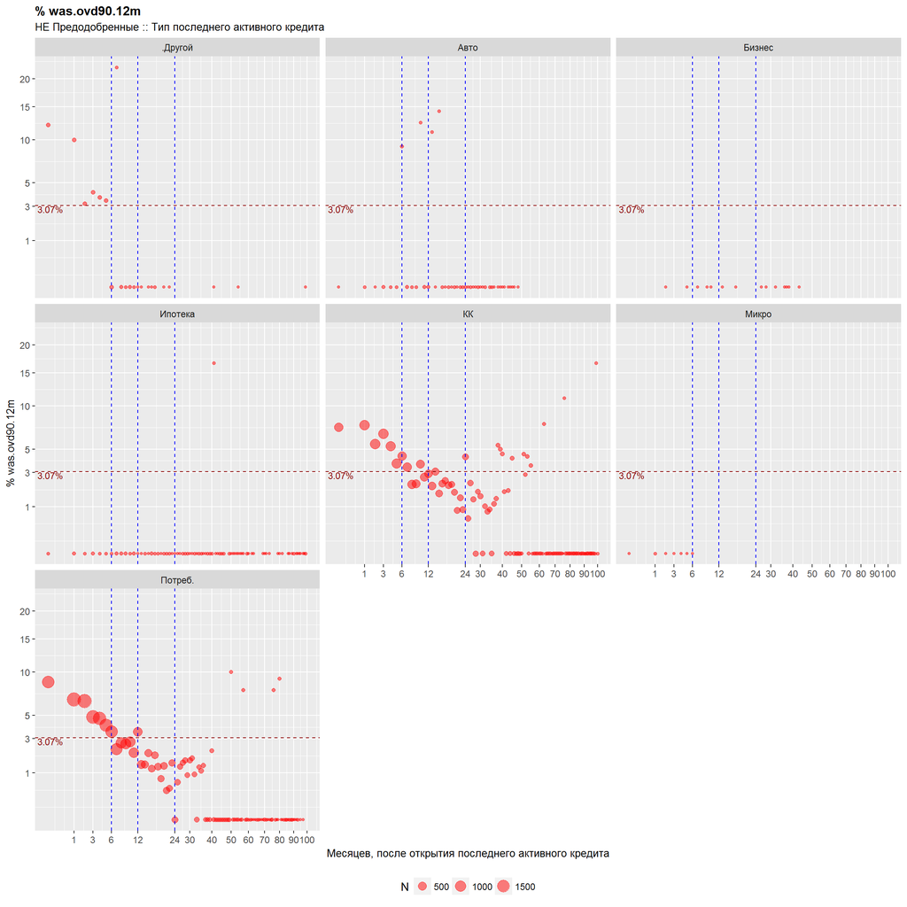

Кол-во выданных (N) и дефолт (was90%) по ним, по времени после открытия последнего активного кредита

| Параметр | ~ | Всего | в т.ч. НЕ имел активных | mon.0 | mon.1 | mon.2 | mon.3 | mon.4 | mon.5 | mon.6 | mon.7 | mon.8 | mon.9 | mon.10 | mon.11 | mon.12 |
| --- | --- | --- | --- | --- | --- | --- | --- | --- | --- | --- | --- | --- | --- | --- | --- | --- |
| NOT Garant:Type:.Другой | N | 261 | NA | 33 | 30 | 31 | 24 | 27 | 29 | 22 | 9 | 14 | 8 | 12 | 5 | 2 |
| NOT Garant:Type:.Другой | was90% | 4.981 | NA | 12.121 | 10 | 3.226 | 4.167 | 3.704 | 3.448 | 0 | 22.222 | 0 | 0 | 0 | 0 | 0 |
| NOT Garant:Type:Missing | N | 13 207 | 13 207 | NA | NA | NA | NA | NA | NA | NA | NA | NA | NA | NA | NA | NA |
| NOT Garant:Type:Missing | was90% | 2.491 | 2.491 | NA | NA | NA | NA | NA | NA | NA | NA | NA | NA | NA | NA | NA |
| NOT Garant:Type:Авто | N | 211 | NA | 2 | 7 | 3 | 11 | 7 | 8 | 11 | 10 | 6 | 7 | 8 | 15 | 10 |
| NOT Garant:Type:Авто | was90% | 1.896 | NA | 0 | 0 | 0 | 0 | 0 | 0 | 9.091 | 0 | 0 | 0 | 12.5 | 0 | 0 |
| NOT Garant:Type:Бизнес | N | 19 | NA | NA | NA | 1 | NA | NA | 2 | NA | 3 | NA | 1 | 1 | NA | NA |
| NOT Garant:Type:Бизнес | was90% | 0 | NA | NA | NA | 0 | NA | NA | 0 | NA | 0 | NA | 0 | 0 | NA | NA |
| NOT Garant:Type:Ипотека | N | 337 | NA | 4 | 10 | 9 | 12 | 8 | 9 | 8 | 11 | 10 | 12 | 9 | 12 | 2 |
| NOT Garant:Type:Ипотека | was90% | 0.297 | NA | 0 | 0 | 0 | 0 | 0 | 0 | 0 | 0 | 0 | 0 | 0 | 0 | 0 |
| NOT Garant:Type:КК | N | 14 559 | NA | 588 | 793 | 804 | 836 | 754 | 724 | 617 | 610 | 594 | 543 | 494 | 489 | 412 |
| NOT Garant:Type:КК | was90% | 3.372 | NA | 7.313 | 7.566 | 5.473 | 6.579 | 5.305 | 3.729 | 4.376 | 3.443 | 2.189 | 2.21 | 3.644 | 2.658 | 2.913 |
| NOT Garant:Type:Микро | N | 13 | NA | 2 | 4 | 3 | 1 | 1 | 1 | 1 | NA | NA | NA | NA | NA | NA |
| NOT Garant:Type:Микро | was90% | 0 | NA | 0 | 0 | 0 | 0 | 0 | 0 | 0 | NA | NA | NA | NA | NA | NA |
| NOT Garant:Type:Потреб. | N | 23 163 | 2 | 1 387 | 1 977 | 1 920 | 1 886 | 1 704 | 1 544 | 1 350 | 1 193 | 1 035 | 945 | 895 | 832 | 624 |
| NOT Garant:Type:Потреб. | was90% | 3.76 | 50 | 8.724 | 6.626 | 6.458 | 4.825 | 4.695 | 4.08 | 3.556 | 2.263 | 2.705 | 2.646 | 2.793 | 2.043 | 3.526 |

#### По принадлежности (true) последнего активного кредита нашему банку:

##### Предодобренные.

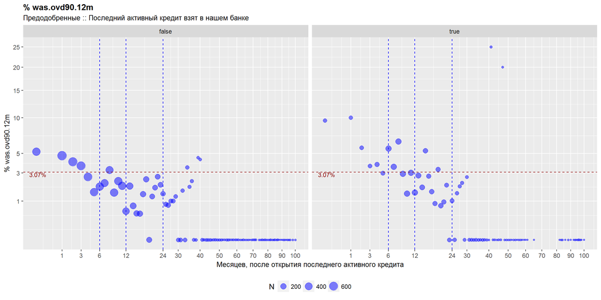

Кол-во выданных (N) и дефолт (was90%) по ним, по времени после открытия последнего активного кредита

| Параметр | ~ | Всего | в т.ч. НЕ имел активных | mon.0 | mon.1 | mon.2 | mon.3 | mon.4 | mon.5 | mon.6 | mon.7 | mon.8 | mon.9 | mon.10 | mon.11 | mon.12 |
| --- | --- | --- | --- | --- | --- | --- | --- | --- | --- | --- | --- | --- | --- | --- | --- | --- |
| Garant:OurBank:false | N | 28 150 | 17 700 | 459 | 697 | 662 | 602 | 562 | 529 | 470 | 419 | 430 | 466 | 476 | 460 | 363 |
| Garant:OurBank:false | was90% | 2.682 | 2.944 | 5.229 | 4.735 | 4.079 | 3.654 | 2.669 | 1.512 | 1.915 | 2.148 | 3.256 | 1.502 | 2.311 | 1.957 | 0.551 |
| Garant:OurBank:true | N | 4 004 | NA | 63 | 60 | 70 | 82 | 105 | 101 | 196 | 195 | 215 | 205 | 208 | 198 | 199 |
| Garant:OurBank:true | was90% | 2.847 | NA | 9.524 | 10 | 5.714 | 3.659 | 3.81 | 2.97 | 5.612 | 3.59 | 6.512 | 2.927 | 1.442 | 3.03 | 1.508 |

##### НЕ предодобренные.

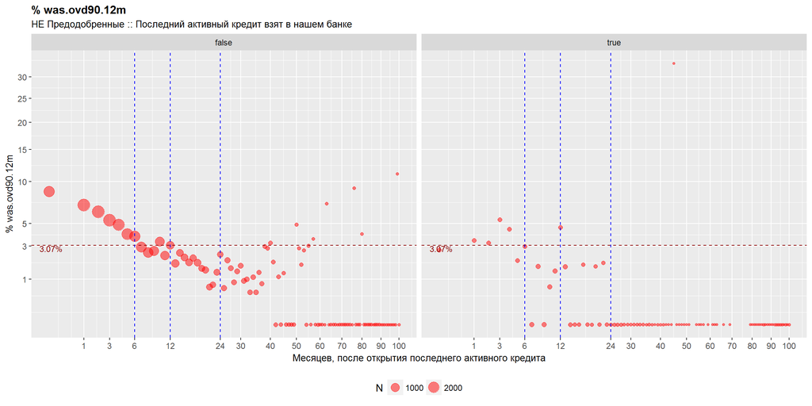

Кол-во выданных (N) и дефолт (was90%) по ним, по времени после открытия последнего активного кредита

| Параметр | ~ | Всего | в т.ч. НЕ имел активных | mon.0 | mon.1 | mon.2 | mon.3 | mon.4 | mon.5 | mon.6 | mon.7 | mon.8 | mon.9 | mon.10 | mon.11 | mon.12 |
| --- | --- | --- | --- | --- | --- | --- | --- | --- | --- | --- | --- | --- | --- | --- | --- | --- |
| NOT Garant:OurBank:false | N | 49 098 | 13 209 | 1 906 | 2 734 | 2 679 | 2 677 | 2 411 | 2 217 | 1 908 | 1 707 | 1 538 | 1 396 | 1 275 | 1 209 | 942 |
| NOT Garant:OurBank:false | was90% | 3.401 | 2.498 | 8.657 | 6.986 | 6.196 | 5.304 | 4.853 | 4.014 | 3.826 | 2.929 | 2.536 | 2.65 | 3.373 | 2.316 | 3.079 |
| NOT Garant:OurBank:true | N | 2 672 | NA | 110 | 87 | 92 | 93 | 90 | 100 | 101 | 129 | 121 | 120 | 144 | 144 | 108 |
| NOT Garant:OurBank:true | was90% | 1.46 | NA | 2.727 | 3.448 | 3.261 | 5.376 | 4.444 | 2 | 2.97 | 0 | 1.653 | 0 | 0.694 | 1.389 | 4.63 |

#### По сегментам:

##### Предодобренные.

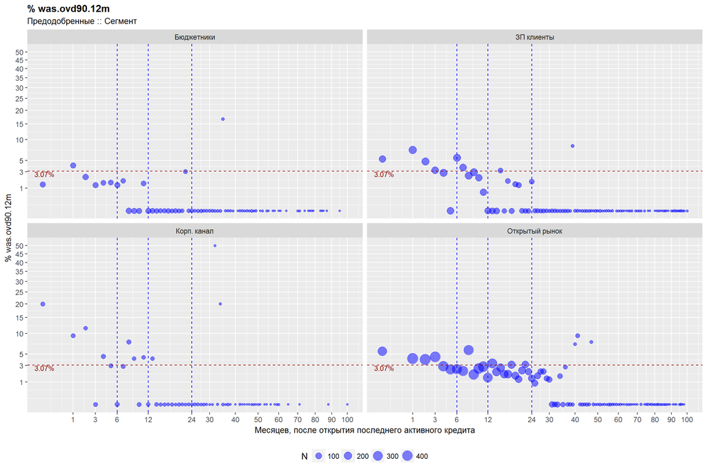

Кол-во выданных (N) и дефолт (was90%) по ним, по времени после открытия последнего активного кредита

| Параметр | ~ | Всего | в т.ч. НЕ имел активных | mon.0 | mon.1 | mon.2 | mon.3 | mon.4 | mon.5 | mon.6 | mon.7 | mon.8 | mon.9 | mon.10 | mon.11 | mon.12 |
| --- | --- | --- | --- | --- | --- | --- | --- | --- | --- | --- | --- | --- | --- | --- | --- | --- |
| Garant:Бюджетники | N | 3 417 | 1 798 | 73 | 74 | 89 | 77 | 65 | 64 | 77 | 56 | 82 | 81 | 80 | 68 | 76 |
| Garant:Бюджетники | was90% | 1.054 | 1.224 | 1.37 | 4.054 | 2.247 | 1.299 | 1.538 | 1.562 | 1.299 | 1.786 | 0 | 0 | 0 | 1.471 | 0 |
| Garant:ЗП клиенты | N | 6 684 | 3 278 | 132 | 192 | 165 | 154 | 174 | 158 | 180 | 162 | 164 | 169 | 139 | 144 | 112 |
| Garant:ЗП клиенты | was90% | 2.244 | 2.288 | 5.303 | 7.292 | 4.848 | 3.247 | 2.874 | 0 | 5.556 | 3.704 | 2.439 | 2.959 | 2.158 | 0.694 | 0 |
| Garant:Корп. канал | N | 856 | 160 | 30 | 32 | 26 | 29 | 44 | 34 | 41 | 35 | 39 | 24 | 34 | 23 | 22 |
| Garant:Корп. канал | was90% | 3.972 | 6.25 | 20 | 9.375 | 11.538 | 0 | 4.545 | 2.941 | 0 | 2.857 | 7.692 | 4.167 | 0 | 4.348 | 0 |
| Garant:Открытый рынок | N | 21 197 | 12 464 | 287 | 459 | 452 | 424 | 384 | 374 | 368 | 361 | 360 | 397 | 431 | 423 | 352 |
| Garant:Открытый рынок | was90% | 3.062 | 3.322 | 5.575 | 4.139 | 3.982 | 4.481 | 2.865 | 2.406 | 2.446 | 2.216 | 5.833 | 1.763 | 2.552 | 2.837 | 1.42 |

##### НЕ предодобренные.

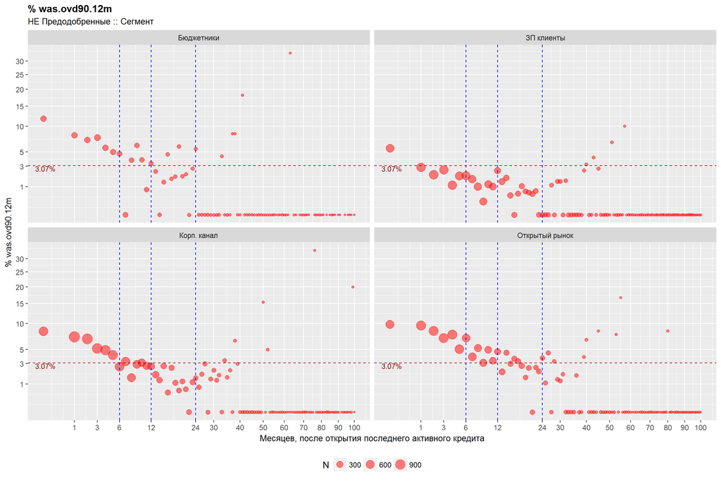

Кол-во выданных (N) и дефолт (was90%) по ним, по времени после открытия последнего активного кредита

| Параметр | ~ | Всего | в т.ч. НЕ имел активных | mon.0 | mon.1 | mon.2 | mon.3 | mon.4 | mon.5 | mon.6 | mon.7 | mon.8 | mon.9 | mon.10 | mon.11 | mon.12 |
| --- | --- | --- | --- | --- | --- | --- | --- | --- | --- | --- | --- | --- | --- | --- | --- | --- |
| NOT Garant:Бюджетники | N | 4 174 | 767 | 205 | 236 | 225 | 251 | 211 | 179 | 169 | 156 | 131 | 130 | 130 | 122 | 90 |
| NOT Garant:Бюджетники | was90% | 4.145 | 2.868 | 11.707 | 8.051 | 7.111 | 7.57 | 5.687 | 5.028 | 4.734 | 0 | 3.817 | 6.154 | 3.846 | 0.82 | 3.333 |
| NOT Garant:ЗП клиенты | N | 15 997 | 5 132 | 550 | 664 | 686 | 660 | 626 | 580 | 565 | 493 | 505 | 453 | 420 | 404 | 282 |
| NOT Garant:ЗП клиенты | was90% | 1.6 | 1.754 | 5.636 | 2.861 | 2.041 | 2.576 | 1.118 | 1.897 | 1.947 | 1.623 | 0.99 | 0.221 | 1.19 | 0.99 | 2.482 |
| NOT Garant:Корп. канал | N | 16 661 | 3 330 | 686 | 1 146 | 1 044 | 996 | 919 | 846 | 730 | 675 | 604 | 513 | 482 | 440 | 376 |
| NOT Garant:Корп. канал | was90% | 3.481 | 2.462 | 8.309 | 7.155 | 6.801 | 5.12 | 4.897 | 4.137 | 2.603 | 3.259 | 1.49 | 2.924 | 3.112 | 2.727 | 2.66 |
| NOT Garant:Открытый рынок | N | 14 938 | 3 980 | 575 | 775 | 816 | 863 | 745 | 712 | 545 | 512 | 419 | 420 | 387 | 387 | 302 |
| NOT Garant:Открытый рынок | was90% | 4.686 | 3.417 | 9.739 | 9.548 | 8.333 | 6.952 | 7.651 | 5.056 | 6.972 | 3.906 | 5.251 | 3.095 | 4.91 | 3.359 | 4.636 |

#### По DBR расчитанному в РАБИС:

##### Предодобренные.

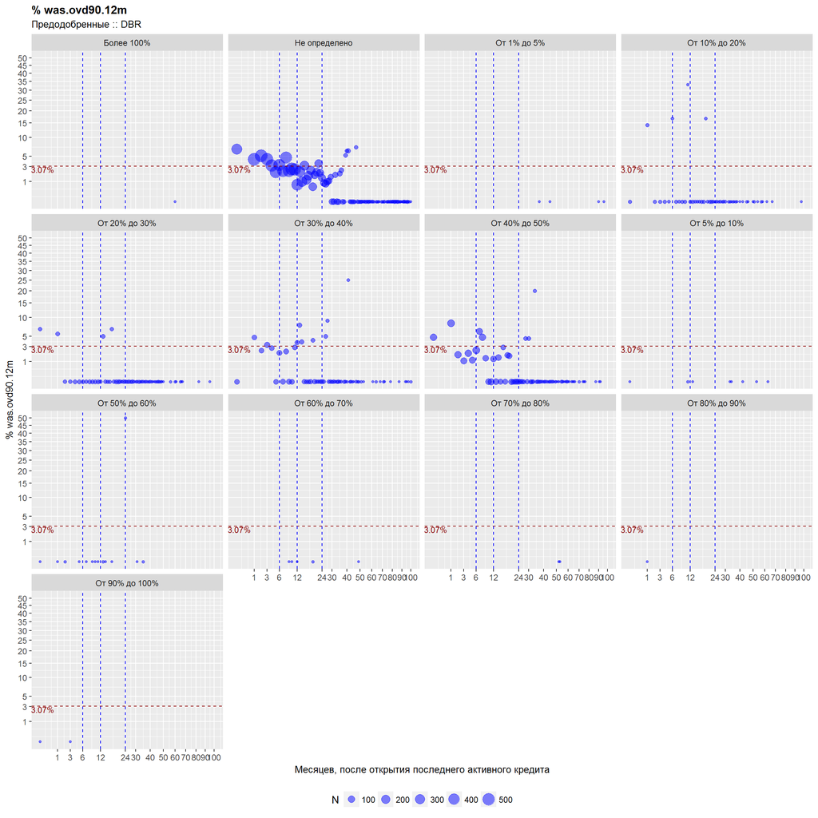

Кол-во выданных (N) и дефолт (was90%) по ним, по времени после открытия последнего активного кредита

| Параметр | ~ | Всего | в т.ч. НЕ имел активных | mon.0 | mon.1 | mon.2 | mon.3 | mon.4 | mon.5 | mon.6 | mon.7 | mon.8 | mon.9 | mon.10 | mon.11 | mon.12 |
| --- | --- | --- | --- | --- | --- | --- | --- | --- | --- | --- | --- | --- | --- | --- | --- | --- |
| Garant:DBR:Более 100% | N | 1 | NA | NA | NA | NA | NA | NA | NA | NA | NA | NA | NA | NA | NA | NA |
| Garant:DBR:Более 100% | was90% | 0 | NA | NA | NA | NA | NA | NA | NA | NA | NA | NA | NA | NA | NA | NA |
| Garant:DBR:Не определено | N | 27 062 | 16 694 | 358 | 556 | 550 | 503 | 502 | 470 | 463 | 444 | 466 | 522 | 547 | 512 | 434 |
| Garant:DBR:Не определено | was90% | 2.864 | 2.989 | 6.704 | 4.317 | 5.091 | 4.374 | 3.187 | 2.128 | 3.24 | 2.252 | 4.721 | 2.299 | 2.559 | 2.539 | 0.691 |
| Garant:DBR:От 1% до 5% | N | 6 | 2 | NA | NA | NA | NA | NA | NA | NA | NA | NA | NA | NA | NA | NA |
| Garant:DBR:От 1% до 5% | was90% | 0 | 0 | NA | NA | NA | NA | NA | NA | NA | NA | NA | NA | NA | NA | NA |
| Garant:DBR:От 10% до 20% | N | 397 | 180 | 8 | 7 | 7 | 11 | 9 | 4 | 6 | 8 | 6 | 7 | 7 | 3 | 8 |
| Garant:DBR:От 10% до 20% | was90% | 1.763 | 1.667 | 0 | 14.286 | 0 | 0 | 0 | 0 | 16.667 | 0 | 0 | 0 | 0 | 33.333 | 0 |
| Garant:DBR:От 20% до 30% | N | 779 | 240 | 15 | 18 | 16 | 15 | 18 | 24 | 24 | 17 | 24 | 20 | 18 | 20 | 12 |
| Garant:DBR:От 20% до 30% | was90% | 1.284 | 2.5 | 6.667 | 5.556 | 0 | 0 | 0 | 0 | 0 | 0 | 0 | 0 | 0 | 0 | 0 |
| Garant:DBR:От 30% до 40% | N | 1 251 | 233 | 34 | 42 | 42 | 60 | 36 | 42 | 50 | 46 | 45 | 44 | 35 | 35 | 27 |
| Garant:DBR:От 30% до 40% | was90% | 1.679 | 1.717 | 0 | 4.762 | 2.381 | 3.333 | 2.778 | 0 | 2 | 0 | 2.222 | 0 | 0 | 2.857 | 3.704 |
| Garant:DBR:От 40% до 50% | N | 2 583 | 315 | 104 | 132 | 114 | 94 | 102 | 89 | 123 | 98 | 104 | 76 | 75 | 85 | 80 |
| Garant:DBR:От 40% до 50% | was90% | 2.091 | 2.54 | 4.808 | 8.333 | 1.754 | 1.064 | 1.961 | 1.124 | 2.439 | 6.122 | 4.808 | 1.316 | 0 | 0 | 1.25 |
| Garant:DBR:От 5% до 10% | N | 41 | 32 | 1 | NA | NA | NA | NA | NA | NA | NA | NA | NA | NA | 2 | NA |
| Garant:DBR:От 5% до 10% | was90% | 2.439 | 3.125 | 0 | NA | NA | NA | NA | NA | NA | NA | NA | NA | NA | 0 | NA |
| Garant:DBR:От 50% до 60% | N | 20 | 1 | 1 | 1 | 3 | NA | NA | 1 | NA | 1 | NA | 1 | 1 | 1 | NA |
| Garant:DBR:От 50% до 60% | was90% | 5 | 0 | 0 | 0 | 0 | NA | NA | 0 | NA | 0 | NA | 0 | 0 | 0 | NA |
| Garant:DBR:От 60% до 70% | N | 7 | 1 | NA | NA | NA | NA | NA | NA | NA | NA | NA | 1 | 1 | NA | 1 |
| Garant:DBR:От 60% до 70% | was90% | 0 | 0 | NA | NA | NA | NA | NA | NA | NA | NA | NA | 0 | 0 | NA | 0 |
| Garant:DBR:От 70% до 80% | N | 2 | NA | NA | NA | NA | NA | NA | NA | NA | NA | NA | NA | NA | NA | NA |
| Garant:DBR:От 70% до 80% | was90% | 0 | NA | NA | NA | NA | NA | NA | NA | NA | NA | NA | NA | NA | NA | NA |
| Garant:DBR:От 80% до 90% | N | 1 | NA | NA | 1 | NA | NA | NA | NA | NA | NA | NA | NA | NA | NA | NA |
| Garant:DBR:От 80% до 90% | was90% | 0 | NA | NA | 0 | NA | NA | NA | NA | NA | NA | NA | NA | NA | NA | NA |
| Garant:DBR:От 90% до 100% | N | 4 | 2 | 1 | NA | NA | 1 | NA | NA | NA | NA | NA | NA | NA | NA | NA |
| Garant:DBR:От 90% до 100% | was90% | 0 | 0 | 0 | NA | NA | 0 | NA | NA | NA | NA | NA | NA | NA | NA | NA |

##### НЕ предодобренные.

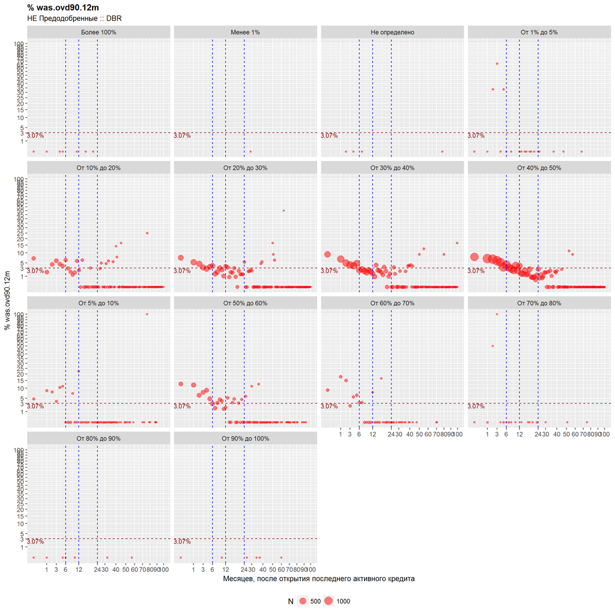

Кол-во выданных (N) и дефолт (was90%) по ним, по времени после открытия последнего активного кредита

| Параметр | ~ | Всего | в т.ч. НЕ имел активных | mon.0 | mon.1 | mon.2 | mon.3 | mon.4 | mon.5 | mon.6 | mon.7 | mon.8 | mon.9 | mon.10 | mon.11 | mon.12 |
| --- | --- | --- | --- | --- | --- | --- | --- | --- | --- | --- | --- | --- | --- | --- | --- | --- |
| NOT Garant:DBR:Более 100% | N | 9 | NA | 1 | 2 | NA | NA | 1 | 2 | NA | NA | NA | NA | NA | 1 | NA |
| NOT Garant:DBR:Более 100% | was90% | 0 | NA | 0 | 0 | NA | NA | 0 | 0 | NA | NA | NA | NA | NA | 0 | NA |
| NOT Garant:DBR:Менее 1% | N | 1 | NA | NA | NA | NA | NA | NA | NA | NA | NA | NA | NA | NA | NA | NA |
| NOT Garant:DBR:Менее 1% | was90% | 0 | NA | NA | NA | NA | NA | NA | NA | NA | NA | NA | NA | NA | NA | NA |
| NOT Garant:DBR:Не определено | N | 277 | 273 | NA | NA | 1 | NA | 1 | NA | NA | 1 | NA | NA | NA | NA | NA |
| NOT Garant:DBR:Не определено | was90% | 2.166 | 2.198 | NA | NA | 0 | NA | 0 | NA | NA | 0 | NA | NA | NA | NA | NA |
| NOT Garant:DBR:От 1% до 5% | N | 44 | 16 | 1 | 2 | 3 | 3 | 1 | 3 | 1 | NA | 1 | NA | NA | NA | 1 |
| NOT Garant:DBR:От 1% до 5% | was90% | 9.091 | 0 | 0 | 0 | 33.333 | 66.667 | 0 | 33.333 | 0 | NA | 0 | NA | NA | NA | 0 |
| NOT Garant:DBR:От 10% до 20% | N | 4 696 | 2 225 | 129 | 157 | 137 | 169 | 155 | 132 | 113 | 100 | 99 | 80 | 110 | 85 | 83 |
| NOT Garant:DBR:От 10% до 20% | was90% | 3.066 | 3.101 | 6.977 | 1.911 | 4.38 | 5.917 | 4.516 | 3.788 | 6.195 | 3 | 2.02 | 1.25 | 1.818 | 5.882 | 2.41 |
| NOT Garant:DBR:От 20% до 30% | N | 9 237 | 3 490 | 284 | 415 | 389 | 364 | 348 | 286 | 255 | 270 | 257 | 220 | 231 | 193 | 162 |
| NOT Garant:DBR:От 20% до 30% | was90% | 2.75 | 2.55 | 7.394 | 5.301 | 4.627 | 3.297 | 2.874 | 3.497 | 3.922 | 1.481 | 1.946 | 3.182 | 2.597 | 1.036 | 3.704 |
| NOT Garant:DBR:От 30% до 40% | N | 12 416 | 3 280 | 449 | 611 | 619 | 656 | 607 | 499 | 453 | 451 | 403 | 377 | 332 | 340 | 262 |
| NOT Garant:DBR:От 30% до 40% | was90% | 2.996 | 2.378 | 9.131 | 6.71 | 5.008 | 4.268 | 3.954 | 4.81 | 2.428 | 2.661 | 2.233 | 1.857 | 2.41 | 2.059 | 1.527 |
| NOT Garant:DBR:От 40% до 50% | N | 21 343 | 3 415 | 930 | 1 350 | 1 350 | 1 326 | 1 139 | 1 142 | 979 | 849 | 769 | 722 | 629 | 642 | 468 |
| NOT Garant:DBR:От 40% до 50% | was90% | 3.486 | 2.196 | 7.849 | 6.815 | 6.667 | 5.882 | 5.18 | 3.327 | 4.29 | 3.298 | 2.861 | 2.355 | 3.975 | 2.336 | 3.846 |
| NOT Garant:DBR:От 5% до 10% | N | 604 | 298 | 21 | 23 | 25 | 26 | 19 | 9 | 9 | 16 | 18 | 14 | 12 | 10 | 9 |
| NOT Garant:DBR:От 5% до 10% | was90% | 3.477 | 2.685 | 4.762 | 8.696 | 8 | 3.846 | 10.526 | 11.111 | 0 | 0 | 0 | 7.143 | 0 | 0 | 22.222 |
| NOT Garant:DBR:От 50% до 60% | N | 2 560 | 197 | 141 | 201 | 192 | 183 | 193 | 190 | 166 | 116 | 92 | 88 | 77 | 65 | 52 |
| NOT Garant:DBR:От 50% до 60% | was90% | 5.039 | 2.538 | 12.766 | 11.94 | 6.25 | 7.65 | 8.808 | 4.737 | 3.012 | 1.724 | 3.261 | 4.545 | 3.896 | 1.538 | 1.923 |
| NOT Garant:DBR:От 60% до 70% | N | 537 | 14 | 56 | 56 | 53 | 42 | 36 | 47 | 30 | 30 | 19 | 15 | 25 | 17 | 13 |
| NOT Garant:DBR:От 60% до 70% | was90% | 6.145 | 0 | 8.929 | 17.857 | 15.094 | 2.381 | 5.556 | 6.383 | 3.333 | 3.333 | 0 | 0 | 0 | 0 | 7.692 |
| NOT Garant:DBR:От 70% до 80% | N | 32 | NA | 2 | 3 | 2 | 1 | 1 | 6 | 2 | 3 | 1 | NA | 1 | NA | NA |
| NOT Garant:DBR:От 70% до 80% | was90% | 6.25 | NA | 0 | 0 | 50 | 100 | 0 | 0 | 0 | 0 | 0 | NA | 0 | NA | NA |
| NOT Garant:DBR:От 80% до 90% | N | 8 | 1 | 1 | 1 | NA | NA | NA | 1 | 1 | NA | NA | NA | 1 | NA | NA |
| NOT Garant:DBR:От 80% до 90% | was90% | 0 | 0 | 0 | 0 | NA | NA | NA | 0 | 0 | NA | NA | NA | 0 | NA | NA |
| NOT Garant:DBR:От 90% до 100% | N | 6 | NA | 1 | NA | NA | NA | NA | NA | NA | NA | NA | NA | 1 | NA | NA |
| NOT Garant:DBR:От 90% до 100% | was90% | 0 | NA | 0 | NA | NA | NA | NA | NA | NA | NA | NA | NA | 0 | NA | NA |

#### По количеству активных кредитов на момент заявки:

##### Предодобренные.

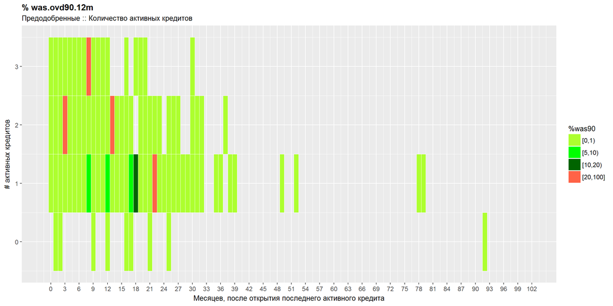

Кол-во выданных (N) и дефолт (was90%) по ним, по времени после открытия последнего активного кредита

| Параметр | ~ | Всего | в т.ч. НЕ имел активных | mon.0 | mon.1 | mon.2 | mon.3 | mon.4 | mon.5 | mon.6 | mon.7 | mon.8 | mon.9 | mon.10 | mon.11 | mon.12 |
| --- | --- | --- | --- | --- | --- | --- | --- | --- | --- | --- | --- | --- | --- | --- | --- | --- |
| Garant:Count active:0 | N | 38 | 28 | NA | 1 | 1 | NA | NA | NA | NA | NA | NA | 1 | NA | NA | 2 |
| Garant:Count active:0 | was90% | 2.632 | 3.571 | NA | 0 | 0 | NA | NA | NA | NA | NA | NA | 0 | NA | NA | 0 |
| Garant:Count active:1 | N | 236 | NA | 2 | 3 | 2 | 3 | 4 | 5 | 9 | 6 | 12 | 13 | 15 | 29 | 17 |
| Garant:Count active:1 | was90% | 2.119 | NA | 0 | 0 | 0 | 0 | 0 | 0 | 0 | 0 | 8.333 | 0 | 0 | 0 | 5.882 |
| Garant:Count active:2 | N | 128 | NA | 5 | 6 | 7 | 6 | 7 | 9 | 8 | 5 | 8 | 11 | 8 | 7 | 6 |
| Garant:Count active:2 | was90% | 2.344 | NA | 0 | 0 | 0 | 33.333 | 0 | 0 | 0 | 0 | 0 | 0 | 0 | 0 | 0 |
| Garant:Count active:3 | N | 43 | NA | 1 | 4 | 4 | 4 | 8 | 1 | 1 | 1 | 5 | 2 | 3 | 2 | 1 |
| Garant:Count active:3 | was90% | 2.326 | NA | 0 | 0 | 0 | 0 | 0 | 0 | 0 | 0 | 20 | 0 | 0 | 0 | 0 |
| Garant:Count active:NA | N | 31 709 | 17 672 | 514 | 743 | 718 | 671 | 648 | 615 | 648 | 602 | 620 | 644 | 658 | 620 | 536 |
| Garant:Count active:NA | was90% | 2.709 | 2.943 | 5.837 | 5.249 | 4.318 | 3.428 | 2.932 | 1.789 | 3.086 | 2.658 | 4.194 | 2.019 | 2.128 | 2.419 | 0.746 |

##### НЕ предодобренные.

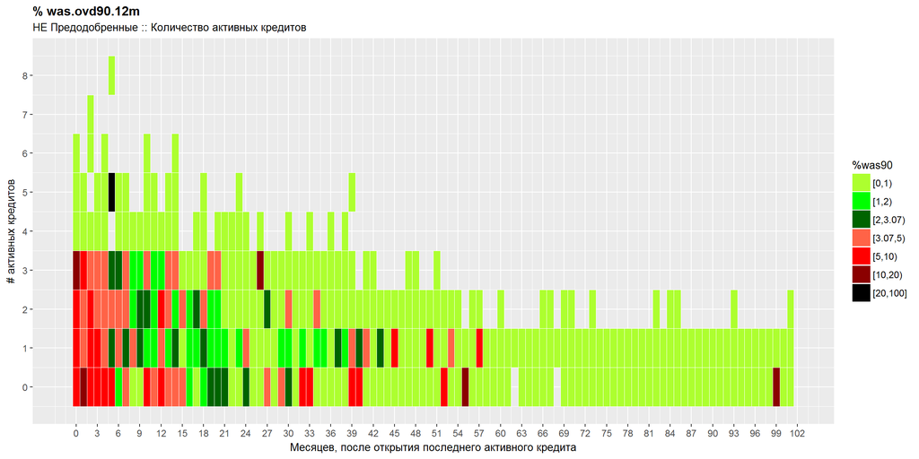

Кол-во выданных (N) и дефолт (was90%) по ним, по времени после открытия последнего активного кредита

| Параметр | ~ | Всего | в т.ч. НЕ имел активных | mon.0 | mon.1 | mon.2 | mon.3 | mon.4 | mon.5 | mon.6 | mon.7 | mon.8 | mon.9 | mon.10 | mon.11 | mon.12 |
| --- | --- | --- | --- | --- | --- | --- | --- | --- | --- | --- | --- | --- | --- | --- | --- | --- |
| NOT Garant:Count active:0 | N | 9 878 | 7 391 | 66 | 88 | 77 | 100 | 97 | 109 | 66 | 81 | 95 | 102 | 114 | 105 | 84 |
| NOT Garant:Count active:0 | was90% | 2.622 | 2.449 | 6.061 | 10.227 | 6.494 | 5 | 6.186 | 5.505 | 1.515 | 4.938 | 0 | 0.98 | 5.263 | 3.81 | 5.952 |
| NOT Garant:Count active:1 | N | 9 764 | 13 | 389 | 515 | 532 | 517 | 488 | 476 | 413 | 391 | 383 | 372 | 353 | 364 | 262 |
| NOT Garant:Count active:1 | was90% | 2.816 | 0 | 7.969 | 4.078 | 6.203 | 6.383 | 3.689 | 2.521 | 4.6 | 2.046 | 3.394 | 2.688 | 1.7 | 1.923 | 3.435 |
| NOT Garant:Count active:2 | N | 5 841 | NA | 365 | 513 | 473 | 512 | 393 | 358 | 297 | 304 | 257 | 254 | 184 | 225 | 173 |
| NOT Garant:Count active:2 | was90% | 3.51 | NA | 8.219 | 4.678 | 5.497 | 3.906 | 4.071 | 4.19 | 3.367 | 3.289 | 1.946 | 2.362 | 2.717 | 1.778 | 5.78 |
| NOT Garant:Count active:3 | N | 2 434 | NA | 214 | 293 | 260 | 227 | 204 | 164 | 139 | 125 | 118 | 80 | 80 | 80 | 71 |
| NOT Garant:Count active:3 | was90% | 3.78 | NA | 10.28 | 5.119 | 3.846 | 3.524 | 4.902 | 2.439 | 2.878 | 4 | 1.695 | 1.25 | 3.75 | 1.25 | 1.408 |
| NOT Garant:Count active:4 | N | 104 | NA | 8 | 5 | 13 | 7 | 10 | NA | 9 | 6 | 6 | 2 | 7 | 2 | 3 |
| NOT Garant:Count active:4 | was90% | 0 | NA | 0 | 0 | 0 | 0 | 0 | NA | 0 | 0 | 0 | 0 | 0 | 0 | 0 |
| NOT Garant:Count active:5 | N | 29 | NA | 4 | 3 | NA | 3 | 4 | 3 | 3 | 1 | NA | NA | 1 | 1 | NA |
| NOT Garant:Count active:5 | was90% | 3.448 | NA | 0 | 0 | NA | 0 | 0 | 33.333 | 0 | 0 | NA | NA | 0 | 0 | NA |
| NOT Garant:Count active:6 | N | 5 | NA | 1 | NA | 1 | NA | 1 | NA | NA | NA | NA | NA | 1 | NA | NA |
| NOT Garant:Count active:6 | was90% | 0 | NA | 0 | NA | 0 | NA | 0 | NA | NA | NA | NA | NA | 0 | NA | NA |
| NOT Garant:Count active:7 | N | 1 | NA | NA | NA | 1 | NA | NA | NA | NA | NA | NA | NA | NA | NA | NA |
| NOT Garant:Count active:7 | was90% | 0 | NA | NA | NA | 0 | NA | NA | NA | NA | NA | NA | NA | NA | NA | NA |
| NOT Garant:Count active:8 | N | 1 | NA | NA | NA | NA | NA | NA | 1 | NA | NA | NA | NA | NA | NA | NA |
| NOT Garant:Count active:8 | was90% | 0 | NA | NA | NA | NA | NA | NA | 0 | NA | NA | NA | NA | NA | NA | NA |
| NOT Garant:Count active:NA | N | 23 713 | 5 805 | 969 | 1 404 | 1 414 | 1 404 | 1 304 | 1 206 | 1 082 | 928 | 800 | 706 | 679 | 576 | 457 |
| NOT Garant:Count active:NA | was90% | 3.698 | 2.567 | 8.359 | 8.903 | 6.719 | 5.769 | 5.445 | 4.395 | 3.882 | 2.478 | 2.625 | 2.691 | 3.535 | 2.431 | 1.969 |

###### *Отчёт подготовлен в среде R*